# Austin Animal Center Intakes Analysis

## Goals of this notebook

We are looking at [Austin Animal Center Intakes](https://data.austintexas.gov/Health-and-Community-Services/Austin-Animal-Center-Intakes/wter-evkm) data, which is animals brought into the official city shelter.

Here are the questions we’ll answer:

- Are animal intakes increasing or decreasing each year since 2016?
- Are there seasonal monthly trends in overall animal intakes?
- Do certain types of animals drive seasonal trends?

## Setup

```r
library(tidyverse)
library(janitor)
library(lubridate)
```

## Import the data

> Will need to change this to github version.

We read in the data from a saved csv file. Could also do this with the RSocrata package.

```r
raw_data <- read_csv("https://github.com/utdata/chj-r-introduction/blob/main/data-prep/chj-aac/data-raw/Austin_Animal_Center_Intakes.csv?raw=true") %>% clean_names()
# peek at table
raw_data %>% nrow()
```

```
[1] 131921
```

```r
raw_data %>% head()
```

| animal_id | name | date_time | month_year | found_location | intake_type | intake_condition | animal_type | sex_upon_intake | age_upon_intake | breed | color |
| --- | --- | --- | --- | --- | --- | --- | --- | --- | --- | --- | --- |
| A786884 | *Brock | 01/03/2019 04:19:00 PM | 01/03/2019 04:19:00 PM | 2501 Magin Meadow Dr in Austin (TX) | Stray | Normal | Dog | Neutered Male | 2 years | Beagle Mix | Tricolor |
| A706918 | Belle | 07/05/2015 12:59:00 PM | 07/05/2015 12:59:00 PM | 9409 Bluegrass Dr in Austin (TX) | Stray | Normal | Dog | Spayed Female | 8 years | English Springer Spaniel | White/Liver |
| A724273 | Runster | 04/14/2016 06:43:00 PM | 04/14/2016 06:43:00 PM | 2818 Palomino Trail in Austin (TX) | Stray | Normal | Dog | Intact Male | 11 months | Basenji Mix | Sable/White |
| A665644 | NA | 10/21/2013 07:59:00 AM | 10/21/2013 07:59:00 AM | Austin (TX) | Stray | Sick | Cat | Intact Female | 4 weeks | Domestic Shorthair Mix | Calico |
| A682524 | Rio | 06/29/2014 10:38:00 AM | 06/29/2014 10:38:00 AM | 800 Grove Blvd in Austin (TX) | Stray | Normal | Dog | Neutered Male | 4 years | Doberman Pinsch/Australian Cattle Dog | Tan/Gray |
| A743852 | Odin | 02/18/2017 12:46:00 PM | 02/18/2017 12:46:00 PM | Austin (TX) | Owner Surrender | Normal | Dog | Neutered Male | 2 years | Labrador Retriever Mix | Chocolate |

### Glimpse to see all at once

```r
raw_data %>% glimpse()
```

```
Rows: 131,921
Columns: 12
$ animal_id        <chr> "A786884", "A706918", "A724273", "A665644", "A682524", "A743852", "A635072", "A7084…
$ name             <chr> "*Brock", "Belle", "Runster", NA, "Rio", "Odin", "Beowulf", "Mumble", NA, NA, "*Cas…
$ date_time        <chr> "01/03/2019 04:19:00 PM", "07/05/2015 12:59:00 PM", "04/14/2016 06:43:00 PM", "10/2…
$ month_year       <chr> "01/03/2019 04:19:00 PM", "07/05/2015 12:59:00 PM", "04/14/2016 06:43:00 PM", "10/2…
$ found_location   <chr> "2501 Magin Meadow Dr in Austin (TX)", "9409 Bluegrass Dr in Austin (TX)", "2818 Pa…
$ intake_type      <chr> "Stray", "Stray", "Stray", "Stray", "Stray", "Owner Surrender", "Public Assist", "P…
$ intake_condition <chr> "Normal", "Normal", "Normal", "Sick", "Normal", "Normal", "Normal", "Normal", "Norm…
$ animal_type      <chr> "Dog", "Dog", "Dog", "Cat", "Dog", "Dog", "Dog", "Dog", "Cat", "Cat", "Cat", "Dog",…
$ sex_upon_intake  <chr> "Neutered Male", "Spayed Female", "Intact Male", "Intact Female", "Neutered Male", …
$ age_upon_intake  <chr> "2 years", "8 years", "11 months", "4 weeks", "4 years", "2 years", "6 years", "2 y…
$ breed            <chr> "Beagle Mix", "English Springer Spaniel", "Basenji Mix", "Domestic Shorthair Mix", …
$ color            <chr> "Tricolor", "White/Liver", "Sable/White", "Calico", "Tan/Gray", "Chocolate", "Black…
```

## Fix a date

This takes a bit to fix the date. An example looks like this;

`01/03/2019 04:19:00 PM`

I need to change this to a real date. I do this by first converting the text to a real date/time value, then extract the date.

```r
date_fix <- raw_data %>%
  mutate(
    intake_date = mdy_hms(date_time) %>% date(),
  )

date_fix %>% glimpse()
```

```
Rows: 131,921
Columns: 13
$ animal_id        <chr> "A786884", "A706918", "A724273", "A665644", "A682524…
$ name             <chr> "*Brock", "Belle", "Runster", NA, "Rio", "Odin", "Be…
$ date_time        <chr> "01/03/2019 04:19:00 PM", "07/05/2015 12:59:00 PM", …
$ month_year       <chr> "01/03/2019 04:19:00 PM", "07/05/2015 12:59:00 PM", …
$ found_location   <chr> "2501 Magin Meadow Dr in Austin (TX)", "9409 Bluegra…
$ intake_type      <chr> "Stray", "Stray", "Stray", "Stray", "Stray", "Owner …
$ intake_condition <chr> "Normal", "Normal", "Normal", "Sick", "Normal", "Nor…
$ animal_type      <chr> "Dog", "Dog", "Dog", "Cat", "Dog", "Dog", "Dog", "Do…
$ sex_upon_intake  <chr> "Neutered Male", "Spayed Female", "Intact Male", "In…
$ age_upon_intake  <chr> "2 years", "8 years", "11 months", "4 weeks", "4 yea…
$ breed            <chr> "Beagle Mix", "English Springer Spaniel", "Basenji M…
$ color            <chr> "Tricolor", "White/Liver", "Sable/White", "Calico", …
$ intake_date      <date> 2019-01-03, 2015-07-05, 2016-04-14, 2013-10-21, 201…
```

## Create some date helpers

- Now that we have dates, we can parse them out to help us later.
- Reselect dates to put them up front and remove old date values.

```r
date_moyr <-date_fix %>%
  mutate(
    yr = year(intake_date) %>% as.character(), # as char to avoid continuous numb
    mo = month(intake_date, label = TRUE),
  ) %>%
  select(intake_date, yr, mo, everything(), -date_time, -month_year)

# peek as table
date_moyr %>% head()
```

| intake_date | yr | mo | animal_id | name | found_location | intake_type | intake_condition | animal_type | sex_upon_intake | age_upon_intake | breed | color |
| --- | --- | --- | --- | --- | --- | --- | --- | --- | --- | --- | --- | --- |
| 2019-01-03 | 2019 | Jan | A786884 | *Brock | 2501 Magin Meadow Dr in Austin (TX) | Stray | Normal | Dog | Neutered Male | 2 years | Beagle Mix | Tricolor |
| 2015-07-05 | 2015 | Jul | A706918 | Belle | 9409 Bluegrass Dr in Austin (TX) | Stray | Normal | Dog | Spayed Female | 8 years | English Springer Spaniel | White/Liver |
| 2016-04-14 | 2016 | Apr | A724273 | Runster | 2818 Palomino Trail in Austin (TX) | Stray | Normal | Dog | Intact Male | 11 months | Basenji Mix | Sable/White |
| 2013-10-21 | 2013 | Oct | A665644 | NA | Austin (TX) | Stray | Sick | Cat | Intact Female | 4 weeks | Domestic Shorthair Mix | Calico |
| 2014-06-29 | 2014 | Jun | A682524 | Rio | 800 Grove Blvd in Austin (TX) | Stray | Normal | Dog | Neutered Male | 4 years | Doberman Pinsch/Australian Cattle Dog | Tan/Gray |
| 2017-02-18 | 2017 | Feb | A743852 | Odin | Austin (TX) | Owner Surrender | Normal | Dog | Neutered Male | 2 years | Labrador Retriever Mix | Chocolate |

## Filter to 5+ years of data

We only want the most recent full five years, plus the most recent full month.

First let’s check what we have with `summary()`.

```r
date_moyr %>% summary()
```

```
  intake_date              yr                  mo         animal_id
 Min.   :2013-10-01   Length:131921      Jun    :13424   Length:131921
 1st Qu.:2015-07-13   Class :character   May    :13397   Class :character
 Median :2017-05-25   Mode  :character   Jul    :12331   Mode  :character
 Mean   :2017-06-14                      Sep    :12049
 3rd Qu.:2019-04-25                      Oct    :11921
 Max.   :2021-10-02                      Aug    :11861
                                         (Other):56938
     name           found_location     intake_type        intake_condition
 Length:131921      Length:131921      Length:131921      Length:131921
 Class :character   Class :character   Class :character   Class :character
 Mode  :character   Mode  :character   Mode  :character   Mode  :character




 animal_type        sex_upon_intake    age_upon_intake       breed
 Length:131921      Length:131921      Length:131921      Length:131921
 Class :character   Class :character   Class :character   Class :character
 Mode  :character   Mode  :character   Mode  :character   Mode  :character




    color
 Length:131921
 Class :character
 Mode  :character
```

### Filter by date

Based on this, let’s do this:

- Filter for later than 2015
- Filter for earlier than Oct 2021
- This is our last data cleaning, so we’ll save as `intakes`.

```r
intakes <- date_moyr %>%
  filter(
    intake_date > "2015-12-31",
    intake_date < "2021-10-01"
  )

# check the result
intakes %>% summary()
```

```
  intake_date              yr                  mo         animal_id
 Min.   :2016-01-01   Length:90299       Jun    : 9440   Length:90299
 1st Qu.:2017-04-24   Class :character   May    : 9346   Class :character
 Median :2018-07-29   Mode  :character   Jul    : 8808   Mode  :character
 Mean   :2018-08-17                      Sep    : 8760
 3rd Qu.:2019-10-02                      Aug    : 8498
 Max.   :2021-09-30                      Apr    : 7258
                                         (Other):38189
     name           found_location     intake_type        intake_condition
 Length:90299       Length:90299       Length:90299       Length:90299
 Class :character   Class :character   Class :character   Class :character
 Mode  :character   Mode  :character   Mode  :character   Mode  :character




 animal_type        sex_upon_intake    age_upon_intake       breed
 Length:90299       Length:90299       Length:90299       Length:90299
 Class :character   Class :character   Class :character   Class :character
 Mode  :character   Mode  :character   Mode  :character   Mode  :character




    color
 Length:90299
 Class :character
 Mode  :character
```

## Animal intakes by year

**Are animal intakes increasing or decreasing each year since 2016?**

We need to count rows based on the year of the record. We need to remove 2021 because it is not a full year.

Then we can chart it.

```r
intakes_yr_data <- intakes %>%
  count(yr, name = "count_animals") %>%
  filter(yr < 2021)

intakes_yr_data
```

| yr | count_animals |
| --- | --- |
| 2016 | 17675 |
| 2017 | 17563 |
| 2018 | 16979 |
| 2019 | 19727 |
| 2020 | 9585 |

Plot the data

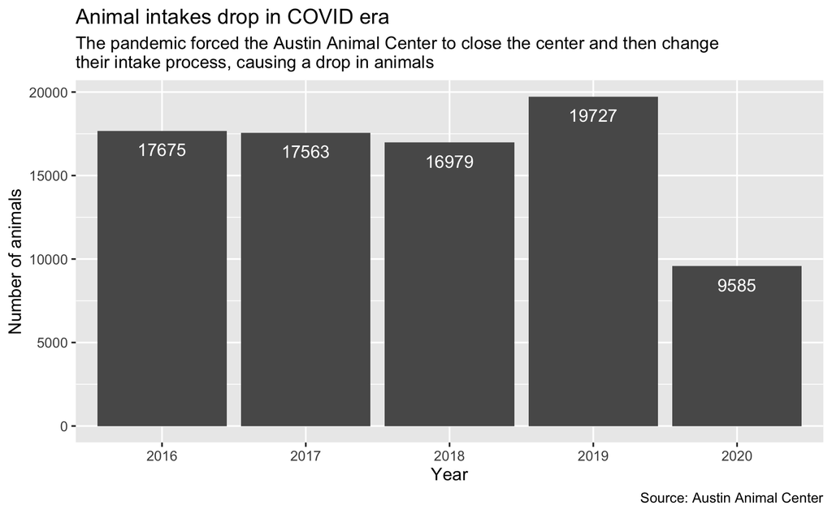

```r
intakes_yr_data %>%
  ggplot(aes(x = yr, y = count_animals)) +
  geom_col() +
  geom_text(aes(label = count_animals), vjust = 2, color = "white") +
  labs(
    title = "Animal intakes drop in COVID era",
    subtitle = str_wrap("The pandemic forced the Austin Animal Center to close the center\nand then change their intake process, causing a drop in animals", 80),
    caption = "Source: Austin Animal Center",
    x = "Year",
    y = "Number of animals"
  )
```

## Intakes by month, split by year

**Are there seasonal monthly trends in overall animal intakes?**

Here we count by both the month name and year.

```r
mo_yr_data <- intakes %>%
  count(mo, yr, name = "count_animals")

mo_yr_data
```

| mo | yr | count_animals |
| --- | --- | --- |
| Jan | 2016 | 1216 |
| Jan | 2017 | 1216 |
| Jan | 2018 | 1123 |
| Jan | 2019 | 1240 |
| Jan | 2020 | 1215 |
| Jan | 2021 | 567 |
| Feb | 2016 | 1194 |
| Feb | 2017 | 1202 |
| Feb | 2018 | 1044 |
| Feb | 2019 | 1131 |

[output cut: 59 more lines]

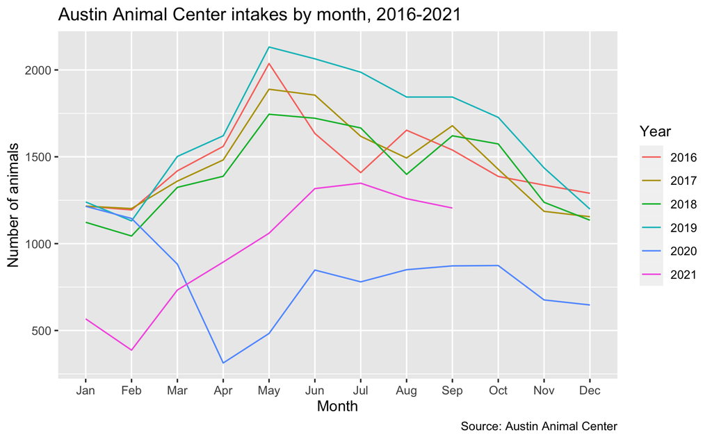

```r
mo_yr_data %>%
  ggplot(aes(x = mo, y = count_animals, group = yr)) +
  geom_line(aes(color = yr)) +
  labs(
    title = "Austin Animal Center intakes by month, 2016-2021",
    color = "Year",
    x = "Month",
    y = "Number of animals",
    caption = "Source: Austin Animal Center"
  )
```

With this we can see a spike in spring months, especially in pre-pandemic data. Let’s figure out why.